# Docking benchmark results

```r
metrics <- readxl::read_excel("DUD-E_results.xlsx", "Table_results", skip=1)

metrics[metrics$System == "MMP13" & metrics$Program == "Vina_1.2.1_AD4", ]$time <- "190:39:19"
metrics[metrics$System == "MMP13" & metrics$Program == "Vina_1.2.1_AD4_norm", ]$time <- "190:39:19"

metrics <- metrics %>%
  filter(!grepl("(rDock_preHTVS|_norm|Z|_bug|_alt)", metrics$Program))


metrics <- metrics %>%
  rowwise() %>%
  mutate(Ligands = case_when(grepl("_SP", System) ~ as.numeric(str_split(node, "_")[[1]][3]),
                             TRUE ~ as.numeric(Ligands)),
         `timelig` = as.numeric(gsub("s", "",
                                     lubridate::as.duration(lubridate::hms(time))/Ligands))) %>%
  ungroup()


colnums <- grep("AUC", colnames(metrics)):length(colnames(metrics))
metrics[, colnums] <- sapply(metrics[,colnums], as.numeric)
```

| Type | Name | System | Ligands | Program | job | node | time | Grid_size | AUC | EF1 | Best_EF1 | EF2,5 | Best_EF2,5 | EF5 | Best_EF5 | EF10 | Best_EF10 | EF20 | Best_EF20 | Top1_xtal_pose_RMSD | 1st_xtal_pose_below_thres_rank | 1st_xtal_pose_below_thres_RMSD | Closest_xtal_pose_rank | Closest_xtal_pose_RMSD | timelig |
| --- | --- | --- | --- | --- | --- | --- | --- | --- | --- | --- | --- | --- | --- | --- | --- | --- | --- | --- | --- | --- | --- | --- | --- | --- | --- |
| Cytochrome P450 | Cytochrome P450 3A4 | CP3A4 | 12303 | AutoDock_GPU | 61981 | 5 | 02:25:51 | 18,8 x 18,8 x 18,8 | 0.534190867767928 | 4.66549707602339 | 69.9824561403509 | 2.10649533532829 | 40.0234113712375 | 1.75541277944024 | 20.0117056856187 | 1.22776238842721 | 9.99749373433584 | 1.05280753073658 | 5.00083577099875 | NA | NA | NA | NA | NA | 0.71128992928554 |
| Cytochrome P450 | Cytochrome P450 3A4 | CP3A4 | 12303 | AutoDock_GPU_new | 63769 | 5 | 07:57:48 | 18,8 x 18,8 x 18,8 | 0.540726578016762 | 4.66549707602339 | 69.9824561403509 | 2.57460540984568 | 40.0234113712375 | 1.98946781669894 | 20.0117056856187 | 1.2862272640666 | 9.99749373433584 | 1.19903079889444 | 5.00083577099875 | NA | NA | NA | NA | NA | 2.33016337478664 |
| Cytochrome P450 | Cytochrome P450 3A4 | CP3A4 | 12303 | Glide | nbdcalc | - | 01:06:09 | 32 x 32 x 32 | 0.597519821613344 | 3.51941176470588 | 70.3882352941176 | 2.35412158174306 | 40.0200668896321 | 2.11870942356876 | 20.0100334448161 | 2.35215489704654 | 9.99665831244779 | 1.64719647992921 | 5.00041788549937 | NA | NA | NA | NA | NA | 0.322604242867593 |
| Cytochrome P450 | Cytochrome P450 3A4 | CP3A4 | 12303 | Glide_resc | nbdcalc | - | 01:09:09 | 32 x 32 x 32 | 0.614761967027324 | 4.10598039215686 | 70.3882352941176 | 3.7665945307889 | 40.0200668896321 | 2.70723981900453 | 20.0100334448161 | 2.35215489704654 | 9.99665831244779 | 1.94133870848799 | 5.00041788549937 | NA | NA | NA | NA | NA | 0.337234820775421 |
| Cytochrome P450 | Cytochrome P450 3A4 | CP3A4 | 12303 | rDock_HTVS | 61983 | 1 | 04:32:12 | 19,5 x 22,5 x 21,5 | 0.606319013513686 | 4.69254901960784 | 70.3882352941176 | 3.5311823726146 | 40.0200668896321 | 2.58953373991737 | 20.0100334448161 | 2.70497813160352 | 9.99665831244779 | 2.08840982276739 | 5.00041788549937 | NA | NA | NA | NA | NA | 1.3274811021702 |
| Cytochrome P450 | Cytochrome P450 3A4 | CP3A4 | 12303 | RxDock_HTVS | 61984 | 1 | 04:09:26 | 19,5 x 22,5 x 21,5 | 0.61348703128596 | 2.9328431372549 | 70.3882352941176 | 3.06035805626598 | 40.0200668896321 | 3.17806413535314 | 20.0100334448161 | 2.46976264189886 | 9.99665831244779 | 1.85309603992036 | 5.00041788549937 | NA | NA | NA | NA | NA | 1.21645127204747 |
| Cytochrome P450 | Cytochrome P450 3A4 | CP3A4 | 12303 | Vina_1.2.0.dev3 | 61967 | 4 | 20:02:35 | 18,8 x 18,8 x 18,8 | 0.580459676092005 | 0.583187134502924 | 69.9824561403509 | 1.17027518629349 | 40.0234113712375 | 1.98946781669894 | 20.0117056856187 | 2.04627064737868 | 9.99749373433584 | 1.63770060336801 | 5.00083577099875 | NA | NA | NA | NA | NA | 5.86482971632935 |
| Cytochrome P450 | Cytochrome P450 3A4 | CP3A4 | 12303 | Vina_1.2.1_AD4 | 61968 | 4 | 37:36:51 | 18,8 x 18,8 x 18,8 | 0.582603414797585 | 2.91593567251462 | 69.9824561403509 | 2.57460540984568 | 40.0234113712375 | 2.92568796573373 | 20.0117056856187 | 1.98780577173929 | 9.99749373433584 | 1.49147733521015 | 5.00083577099875 | NA | NA | NA | NA | NA | 11.0063399170934 |
| Cytochrome P450 | Cytochrome P450 3A4 | CP3A4_SP | 1240 | AutoDock_GPU | nbdcalc | -_1197_1240 | 07:30:17 | 32 x 32 x 32 | 0.641796631316286 | 4.75 | 57 | 5.7 | 39.9 | 3.8 | 19.95 | 2.85 | 9.975 | 2.38493723849372 | 5.00836820083682 | NA | NA | NA | NA | NA | 21.7879032258065 |
| Cytochrome P450 | Cytochrome P450 3A4 | CP3A4_SP | 1290 | Glide | nbdcalc | -_1197_1290 | 06:13:42 | 32 x 32 x 32 | 0.566041482789053 | 0 | 29.925 | 2.9925 | 29.925 | 1.995 | 19.95 | 1.745625 | 9.975 | 1.87813807531381 | 5.00836820083682 | NA | NA | NA | NA | NA | 17.3813953488372 |

[output cut: 402 more lines]

# 1 Enrichment factors

Figure 1.1: Heatmaps of normalized Enrichment Factors at different %s for the different programs and systems. The program that yields the best value for each system in each case is highlighted with a point. Normalization of EFs is performed by dividing each EF value by the best possible value that can be obtained for the corresponding % (which depends on the library size and amount of actives in it) and then applying a log10 transformation (0,001 is added to all values to avoid zeroes). Rows (systems) are sliced by type of system, according to the left annotation. Columns (programs) are sorted by decreasing value of average EF across all systems for each % and column annotation shows the average of this normalized EF across all systems, for each program at each % (values shown are 10^x).

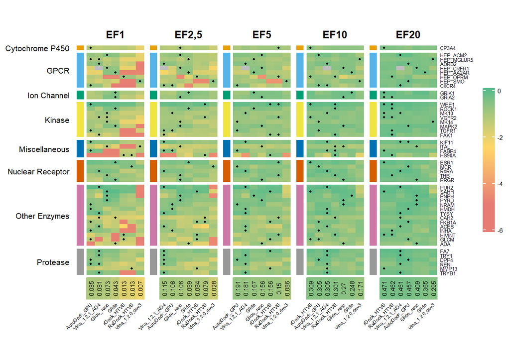

Given the previous results, Glide SPs were run for some systems, using the top 10% ligands from AutoDock-GPU, rDock and Glide results. They are shown together below (SPs are visually identifiable because they have many grey rectangles, corresponding to the missing data of the programs for which SP wasn’t run). So far, both AutoDock-GPU and rDock HTVS yield the best, similar results.

Figure 1.2: Heatmaps of normalized Enrichment Factors at different %s for the different programs and systems, **including SP results**. The program that yields the best value for each system in each case is highlighted with a point. Normalization of EFs is performed by dividing each EF value by the best possible value that can be obtained for the corresponding % (which depends on the library size and amount of actives in it) and then applying a log10 transformation (0,001 is added to all values to avoid zeroes). Rows (systems) are sliced by type of system, according to the left annotation. Columns (programs) are sorted by decreasing value of average EF across all systems for each % and column annotation shows the average of this normalized EF across all systems, for each program at each % (values shown are 10^x).

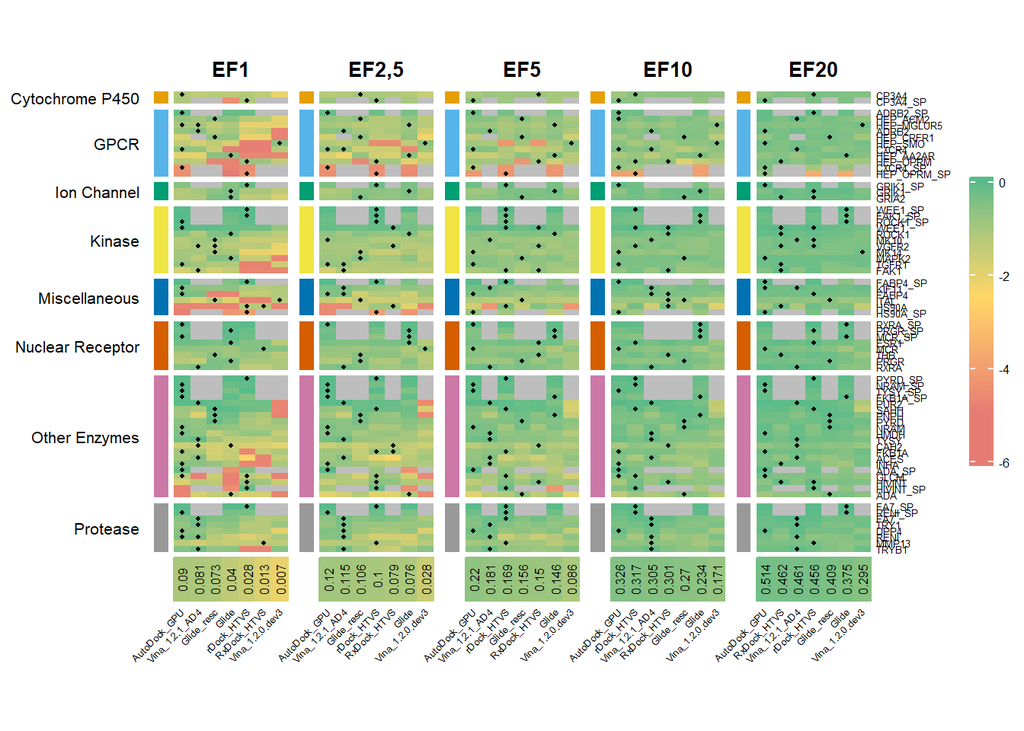

Since the top 10% ligands from HTVS results were used for SP and rDock yielded the best normalized EFs at that percentage, it’s to be expected that it also gives the best metrics for the SP runs. However, since AutoDock-GPU gives the best results at lower EF %s and it’s the fastest one after Glide (while rDock can take triple the time; check next section), it still should be the optimum program to focus on. *As I commented before, AutoDock GPU’s new version doesn’t produce a dramatic enhancement of the results over the old version.*

Figure 1.3: Heatmaps of normalized Enrichment Factors at different %s for the systems and programs for which **Glide SP** has been run. Individual values are shown and the average normalized EF across all systems for each program and % is included below each column (columns (programs) are sorted by decreasing value of average EF across all systems for each %) (values shown are 10^x). Normalization of EFs is performed by dividing each EF value by the best possible value that can be obtained for the corresponding % (which depends on the library size and amount of actives in it) and then applying a log10 transformation (0,001 is added to all values to avoid zeroes).

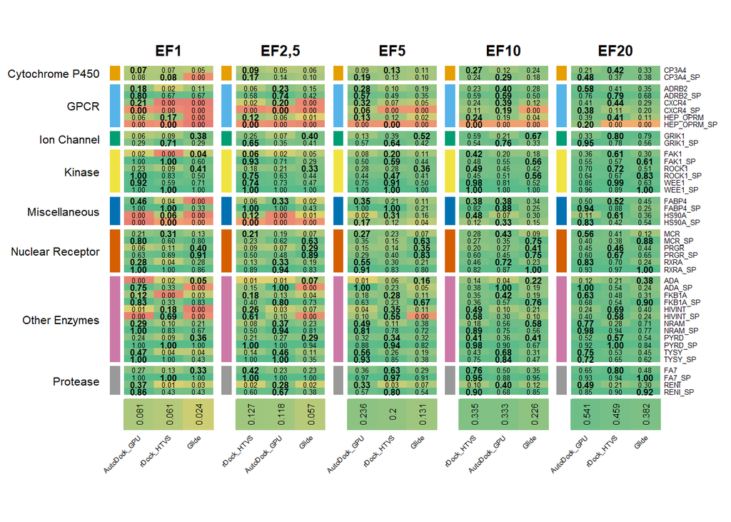

Figure 1.4: Heatmaps of normalized Enrichment Factors at different %s for the systems and programs for which **AutoDock_GPU_new** has been run. Individual values are shown and the average normalized EF across all systems for each program and % is included below each column (columns (programs) are sorted by decreasing value of average EF across all systems for each %) (values shown are 10^x). Normalization of EFs is performed by dividing each EF value by the best possible value that can be obtained for the corresponding % (which depends on the library size and amount of actives in it) and then applying a log10 transformation (0,001 is added to all values to avoid zeroes).

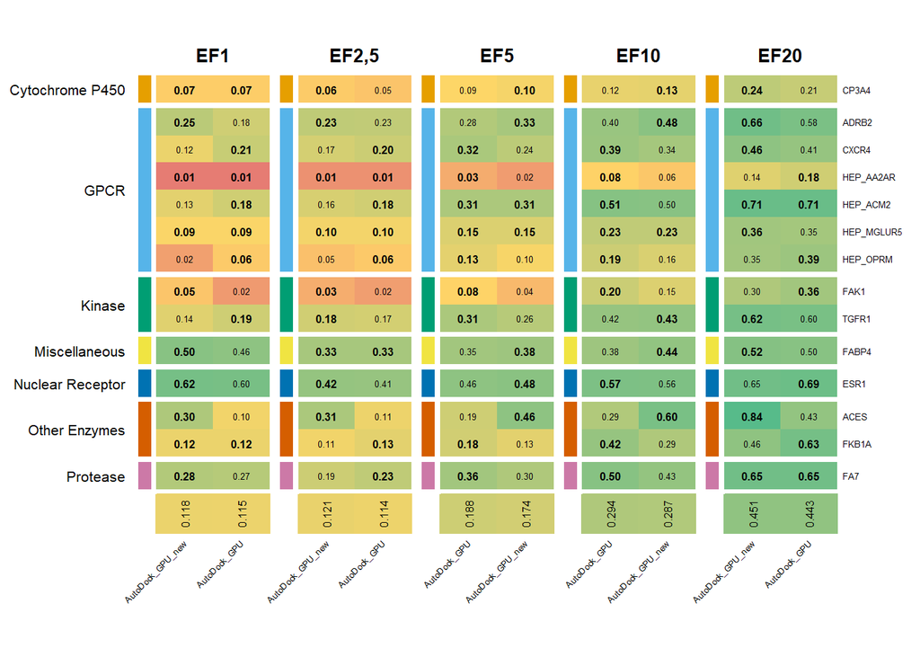

# 2 AUC and time per ligand

The first image, without the SP results, shows that for AutoDock GPU and rDock achieve a similar AUC and, again, surprisingly, outperform Glde. However, Glide is the fastest while AutoDock takes around twice the time and rDock three times more. The new version of AutoDock Vina (1.2.x) with AutoDock4 scoring function achieves great results, but it is extremely slow. The new version of Vina with its own scoring function is also slow and the results are surprisingly bad. *Also, since AutoDock GPU’s new version can’t be parallelized at the moment, it is considerably slower than the old version.*

Below there is a table with **estimated average durations** for the HTVS docking of 1 million compounds for each program.

Figure 2.1: Heatmaps of AUC values and time per ligand (time divided by total ligands). As before, rows (systems) are sliced by type of system, according to the left annotation and columns (programs) are sorted by decreasing (or increasing, respectively) value of the average of the metric across all systems. The program that yields the best value for each system in each case is highlighted with a point. Upper legend corresponds to AUC heatmap and the bottom one to time per ligand.

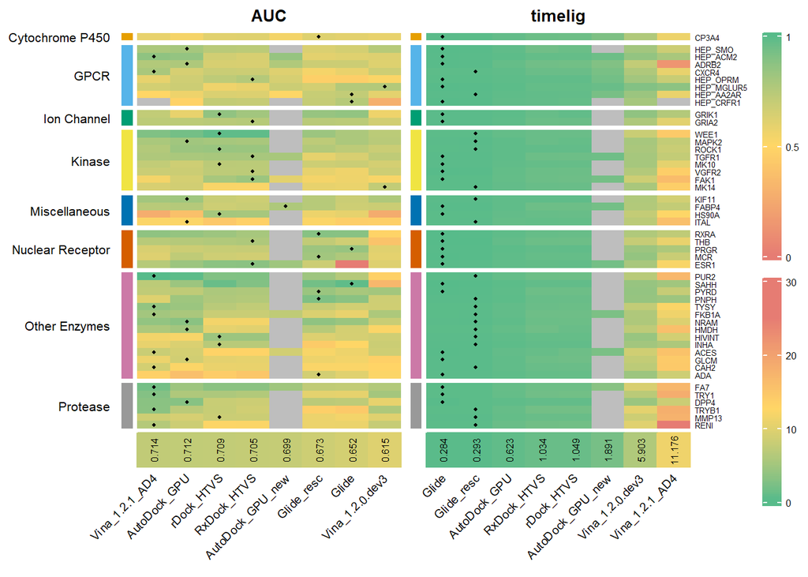

**Estimated average durations for 1M ligands**

| Program | Time per 1M ligs | Cluster | GPUs | ntasks | multiprocessing* |
| --- | --- | --- | --- | --- | --- |
| Glide | 283718.989588178s (~3.28 days) | nbdcalc01 |  | -NJOBS 1 |  |
| Glide_resc | 292690.83761233s (~3.39 days) | nbdcalc01 |  | -NJOBS 1 |  |
| AutoDock_GPU | 623199.864455361s (~1.03 weeks) | cluster | 1 | 11 | 24 processes, (4 CPUs each) |
| RxDock_HTVS | 1033784.83781386s (~1.71 weeks) | cluster |  | 11 | 16 processes, (16 CPUs each) |
| rDock_HTVS | 1049054.94204986s (~1.73 weeks) | cluster |  | 11 | 16 processes, (16 CPUs each) |
| AutoDock_GPU_new | 1891012.79182427s (~3.13 weeks) | cluster | 1 | 11 | no parallelization |
| Vina_1.2.0.dev3 | 5902598.28872985s (~9.76 weeks) | cluster |  | 11 | 24 processes, 4 CPUs each |
| Vina_1.2.1_AD4 | 11175827.2753565s (~18.48 weeks) | cluster |  | 11 | 24 processes, 4 CPUs each |

*multiprocessing: I did some testing at the beginning of the internship to find these optimal parameters of the “multiprocessing” module (number of parallel processes and number of CPUs for each one) to run Vina, AutoDock and the rDocks at the highest speed. The older version of AutoDock is able to be run with multiprocessing while the new one still does not and is thus slower so far. CPUs in parentheses means that, while in the testing that was the optimal number of CPUs found, the number isn’t used anywhere (Vina is the only one that has a flag “-cpu 4”).

Figure 2.2: Heatmaps of AUC values and time per ligand (time divided by total ligands), **including SP results**. As before, rows (systems) are sliced by type of system, according to the left annotation and columns (programs) are sorted by decreasing (or increasing, respectively) value of the average of the metric across all systems. The program that yields the best value for each system in each case is highlighted with a point. Upper legend corresponds to AUC heatmap and the bottom one to time per ligand.

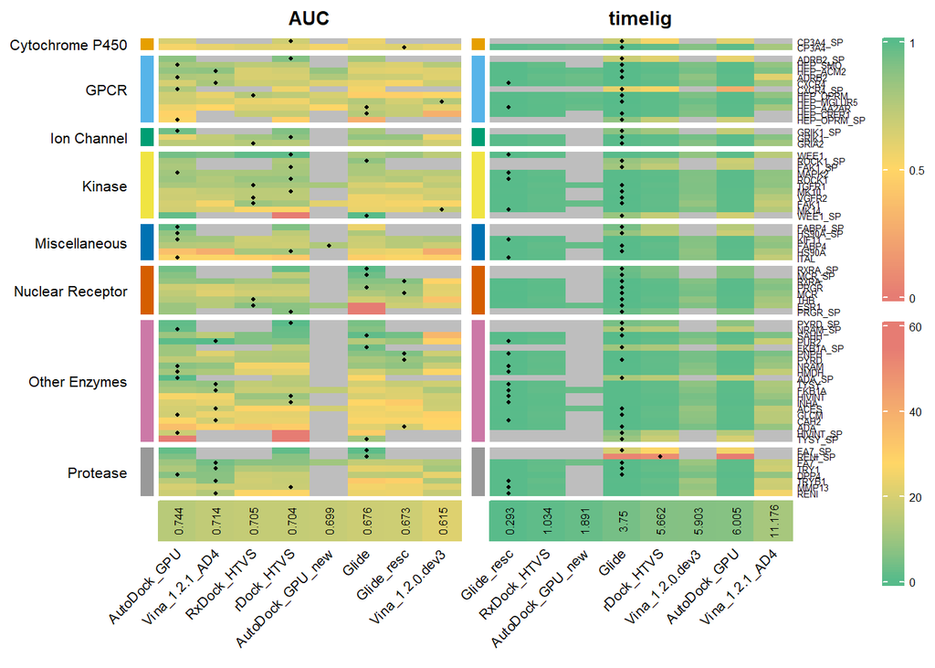

# 3 EF per system type

Figure to detect possible outlier systems.

Figure 3.1: Line plots for normalized Enrichment Factors at all % for all systems and programs, separating by type of system. **Black line** represents the average line in each plot (without including the SP results) and tiny tags next to some of the AutoDock-GPU graphs indicate the SP lines.

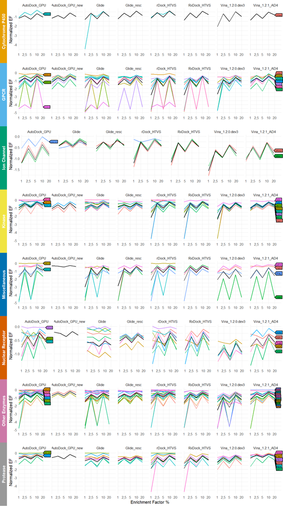